# HW2_SERCAN_BÖÇKÜN_2019402123

Sercan Böçkün

2022-05-07

Installing required libraries and preparing the data

```r
require(data.table)
require(lubridate)
require(forecast)
```

```r
require(ggplot2)
require(GGally)
############# Reading and processing datas ##########
data_path="C:/Users/serca/OneDrive/Masaüstü/Spring 22'/IE 360/HW_2/IE360_Spring22_HW2_data.csv"
data=read.csv(data_path)

data$Unleaded.Gasoline.Sale..UGS. = gsub( " ", "", data$Unleaded.Gasoline.Sale..UGS. )
data$Unleaded.Gasoline.Sale..UGS. = as.numeric(data$Unleaded.Gasoline.Sale..UGS.)

data$X..LPG.Vehicles..NLPG. = gsub( " ", "", data$X..LPG.Vehicles..NLPG. )
data$X..LPG.Vehicles..NLPG. = as.numeric(data$X..LPG.Vehicles..NLPG)

data$X..Unleaded.Gasoline.Vehicles..NUGV. = gsub( " ", "", data$X..Unleaded.Gasoline.Vehicles..NUGV. )
data$X..Unleaded.Gasoline.Vehicles..NUGV. = as.numeric(data$X..Unleaded.Gasoline.Vehicles..NUGV.)

data$GNP.Agriculture = gsub( " ", "", data$GNP.Agriculture )
data$GNP.Agriculture = as.numeric(data$GNP.Agriculture)

data$GNP.Commerce = gsub( " ", "", data$GNP.Commerce )
data$GNP.Commerce = as.numeric(data$GNP.Commerce)

data$GNP.Total = gsub( " ", "", data$GNP.Total )
data$GNP.Total = as.numeric(data$GNP.Total)


data$Quarter = as.character(data$Quarter)
#data$Quarter <- as.Date(data$Quarter)

data = data.table(data)

head(data,25)
```

```
##     Quarter Unleaded.Gasoline.Sale..UGS.   RNUV X..LPG.Vehicles..NLPG.
##  1: 2000_Q1                      1128971 0.0146                 940000
##  2: 2000_Q2                      1199569 0.0205                 941000
##  3: 2000_Q3                      1370167 0.0207                 943500
##  4: 2000_Q4                      1127548 0.0163                 948000
##  5: 2001_Q1                      1033918 0.0071                 950000
##  6: 2001_Q2                      1019754 0.0051                 955000
##  7: 2001_Q3                      1209916 0.0041                 967500
##  8: 2001_Q4                      1002789 0.0048                 990000
##  9: 2002_Q1                       893722 0.0012                1000000
## 10: 2002_Q2                      1027252 0.0032                1001000
## 11: 2002_Q3                      1153265 0.0034                1003500
## 12: 2002_Q4                       991981 0.0044                1008000
## 13: 2003_Q1                       806257 0.0019                1010000
## 14: 2003_Q2                       960556 0.0056                1048000
```

[output cut: 93 more lines]

```r
str(data)
```

```
## Classes 'data.table' and 'data.frame':   32 obs. of  11 variables:
##  $ Quarter                              : chr  "2000_Q1" "2000_Q2" "2000_Q3" "2000_Q4" ...
##  $ Unleaded.Gasoline.Sale..UGS.         : num  1128971 1199569 1370167 1127548 1033918 ...
##  $ RNUV                                 : num  0.0146 0.0205 0.0207 0.0163 0.0071 0.0051 0.0041 0.0048 0.0012 0.0032 ...
##  $ X..LPG.Vehicles..NLPG.               : num  940000 941000 943500 948000 950000 ...
##  $ Price.of.Unleaded.Gasoline..PU.      : num  469 459 440 402 412 ...
##  $ Price.of.Diesel.Gasoline..PG.        : num  356 345 327 301 306 ...
##  $ X..Unleaded.Gasoline.Vehicles..NUGV. : num  4647500 4742876 4840931 4919685 4954754 ...
##  $ X..of.Diesel.Gasoline.Vehicles..NDGV.: num  282 284 287 288 288 ...
##  $ GNP.Agriculture                      : num  1040173 1760460 6974808 3267125 1004528 ...
##  $ GNP.Commerce                         : num  3483132 4525451 5915204 4929778 3418387 ...
##  $ GNP.Total                            : num  18022686 21797130 30050207 24480153 15832648 ...
##  - attr(*, ".internal.selfref")=<externalptr>
```

## 0. Introduction

In this document statistical analysis and regression models will be discussed and applied to the dataset which was presented in the previous section. The last 4 rows of the “Unleaded.Gasoline.Sale..UGS.” column is missing and represents the unleaded gasoline sales in a given quarter.

## 1. Plotting and Commenting on the UGS

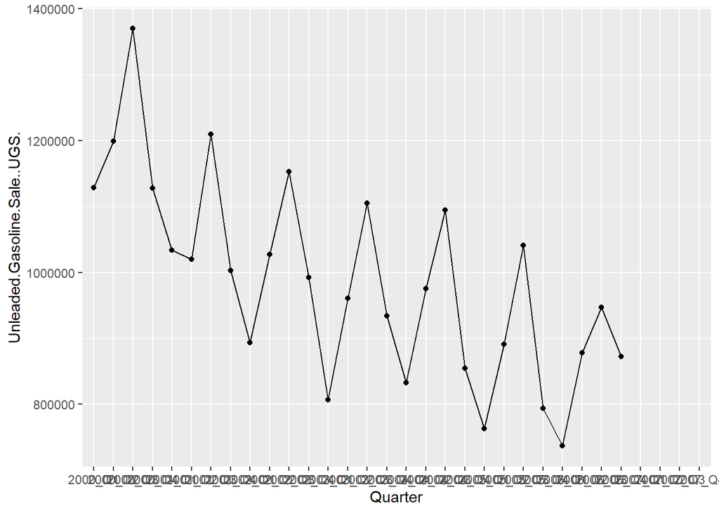

```r
data$Unleaded.Gasoline.Sale..UGS. = ts(data$Unleaded.Gasoline.Sale..UGS., start = 2000, deltat= 1/4)

ggplot(data, aes(Quarter,Unleaded.Gasoline.Sale..UGS. , group=1)) + geom_line() +geom_point()
```

Looking at the shape of the plot it can be observed that the number of sales have a decreasing trend with seasonal peaks and lows. Visiting back to the definition of stationary we know that stationary time series data is not predictable since it has no any detectable trend and seasonality. Our UGS data is clearly shrinking with a slight decrase in it’s variance. We conclude that the data is not stationary thus prediction models can be prepared at tested.

## 2. Looking at the Autocorrelation of UGS

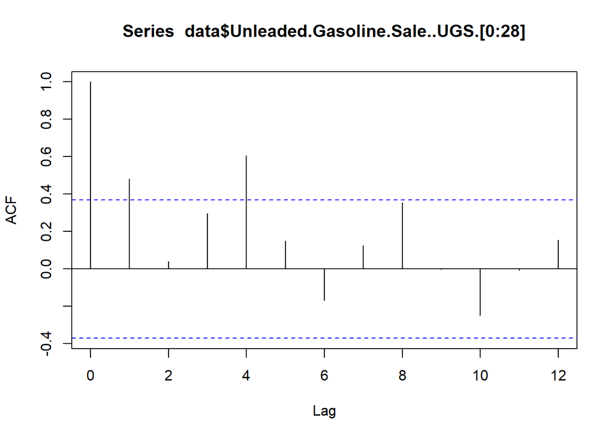

```r
acf(data$Unleaded.Gasoline.Sale..UGS.[0:28], 12) # The last 4 values are missing. We use the available data to measure autocorrelation func.
```

Above plotting shows the autocorrelation of the UGS sales. One can easily detect that ACF is having peaks with lags that are multiplier of 4. This is a indication of seasonality with respect to quarters.

## 3. Adding Seasonality and Trend data

```r
data[,trend:=1:.N] # Adding the trend factor as a column to the data

data[,seasonality:=((1:.N)%%4)] # remainder from 4. 4th quarters are represented with "0".
data[seasonality == 0, seasonality := 4]
data$seasonality = as.factor(data$seasonality) # Taking seasonality as factor

str(data)
```

```
## Classes 'data.table' and 'data.frame':   32 obs. of  13 variables:
##  $ Quarter                              : chr  "2000_Q1" "2000_Q2" "2000_Q3" "2000_Q4" ...
##  $ Unleaded.Gasoline.Sale..UGS.         : Time-Series  from 2000 to 2008: 1128971 1199569 1370167 1127548 1033918 ...
##  $ RNUV                                 : num  0.0146 0.0205 0.0207 0.0163 0.0071 0.0051 0.0041 0.0048 0.0012 0.0032 ...
##  $ X..LPG.Vehicles..NLPG.               : num  940000 941000 943500 948000 950000 ...
##  $ Price.of.Unleaded.Gasoline..PU.      : num  469 459 440 402 412 ...
##  $ Price.of.Diesel.Gasoline..PG.        : num  356 345 327 301 306 ...
##  $ X..Unleaded.Gasoline.Vehicles..NUGV. : num  4647500 4742876 4840931 4919685 4954754 ...
##  $ X..of.Diesel.Gasoline.Vehicles..NDGV.: num  282 284 287 288 288 ...
##  $ GNP.Agriculture                      : num  1040173 1760460 6974808 3267125 1004528 ...
##  $ GNP.Commerce                         : num  3483132 4525451 5915204 4929778 3418387 ...
##  $ GNP.Total                            : num  18022686 21797130 30050207 24480153 15832648 ...
##  $ trend                                : int  1 2 3 4 5 6 7 8 9 10 ...
##  $ seasonality                          : Factor w/ 4 levels "1","2","3","4": 1 2 3 4 1 2 3 4 1 2 ...
##  - attr(*, ".internal.selfref")=<externalptr>
##  - attr(*, "index")= int(0)
```

## 4. Building Regression Models

Before starting to building models let’s take a look at the correlation matrix to have a better understanding of the data.

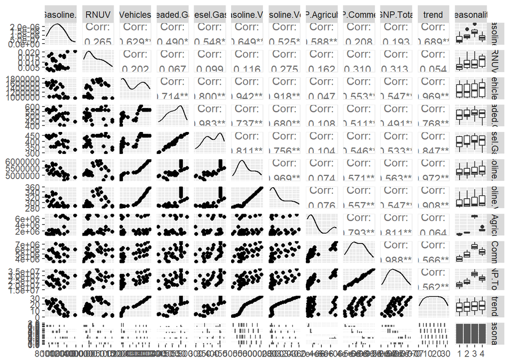

```r
ggpairs(data[,-1,with=FALSE]) # We will build our model with the variables which are in high correlation with our output variable
```

Base Model:

```r
model_0= lm(Unleaded.Gasoline.Sale..UGS.~trend ,data)
summary(model_0)
```

```
##
## Call:
## lm(formula = Unleaded.Gasoline.Sale..UGS. ~ trend, data = data)
##
## Residuals:
##     Min      1Q  Median      3Q     Max
## -199945  -73550  -21904   71224  237369
##
## Coefficients:
##             Estimate Std. Error t value Pr(>|t|)
## (Intercept)  1170777      43293  27.043  < 2e-16 ***
## trend         -12660       2608  -4.854 4.95e-05 ***
## ---
## Signif. codes:  0 '***' 0.001 '**' 0.01 '*' 0.05 '.' 0.1 ' ' 1
##
## Residual standard error: 111500 on 26 degrees of freedom
##   (4 observations deleted due to missingness)
## Multiple R-squared:  0.4754, Adjusted R-squared:  0.4552
## F-statistic: 23.56 on 1 and 26 DF,  p-value: 4.945e-05
```

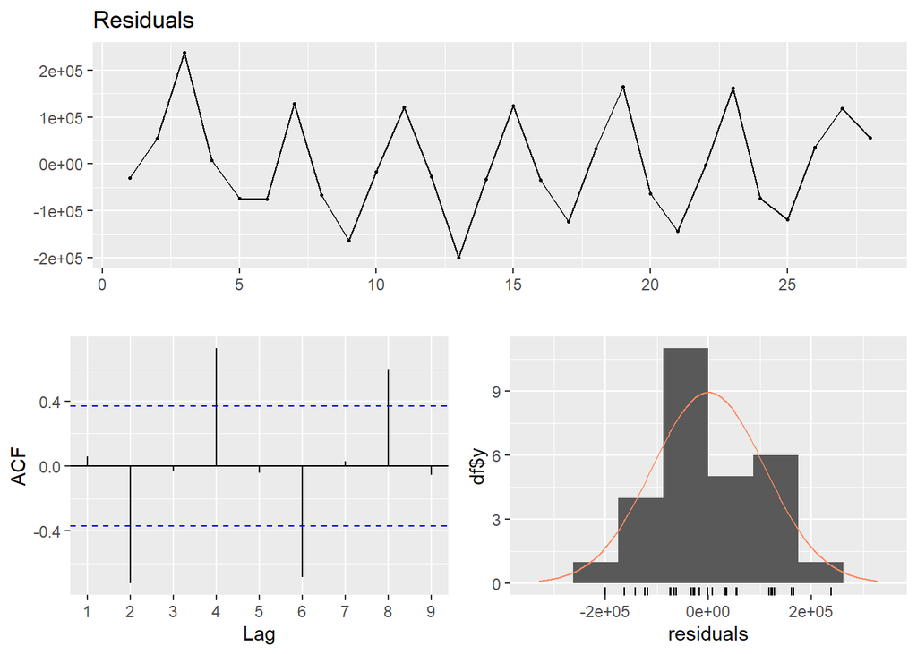

```r
checkresiduals(model_0$residuals) # There's high autocorrelation with lag 2 and 4's
```

Adding seasonality and trend to the base model.

```r
model_1= lm(Unleaded.Gasoline.Sale..UGS.~trend + seasonality,data) # One of the seasonality is omitted into the intercept
summary(model_1)
```

```
##
## Call:
## lm(formula = Unleaded.Gasoline.Sale..UGS. ~ trend + seasonality,
##     data = data)
##
## Residuals:
##    Min     1Q Median     3Q    Max
## -81167 -31283  -3458  28640  94502
##
## Coefficients:
##              Estimate Std. Error t value Pr(>|t|)
## (Intercept)   1060372      23653  44.830  < 2e-16 ***
## trend          -13497       1147 -11.764 3.28e-11 ***
## seasonality2   121532      25987   4.677 0.000104 ***
## seasonality3   273619      26063  10.498 3.03e-10 ***
## seasonality4    95049      26189   3.629 0.001405 **
## ---
## Signif. codes:  0 '***' 0.001 '**' 0.01 '*' 0.05 '.' 0.1 ' ' 1
##
## Residual standard error: 48570 on 23 degrees of freedom
##   (4 observations deleted due to missingness)
## Multiple R-squared:  0.9119, Adjusted R-squared:  0.8966
## F-statistic: 59.53 on 4 and 23 DF,  p-value: 8.446e-12
```